# Tutorial 1 - Intro to R, Rstudio and RMarkdown; Basic Data Exploration and Manipulation

#### One Continuous and One Categorical Variable

Here again we have a lot of choices, but one I like is boxplots *plus the raw data* (if your sample size isn’t too huge). For other options, I recommend reviewing [this website](https://www.r-graph-gallery.com/).

Anyway, here’s some code to look at the distribution of stolen bases by League (AL vs. NL) in 2022:

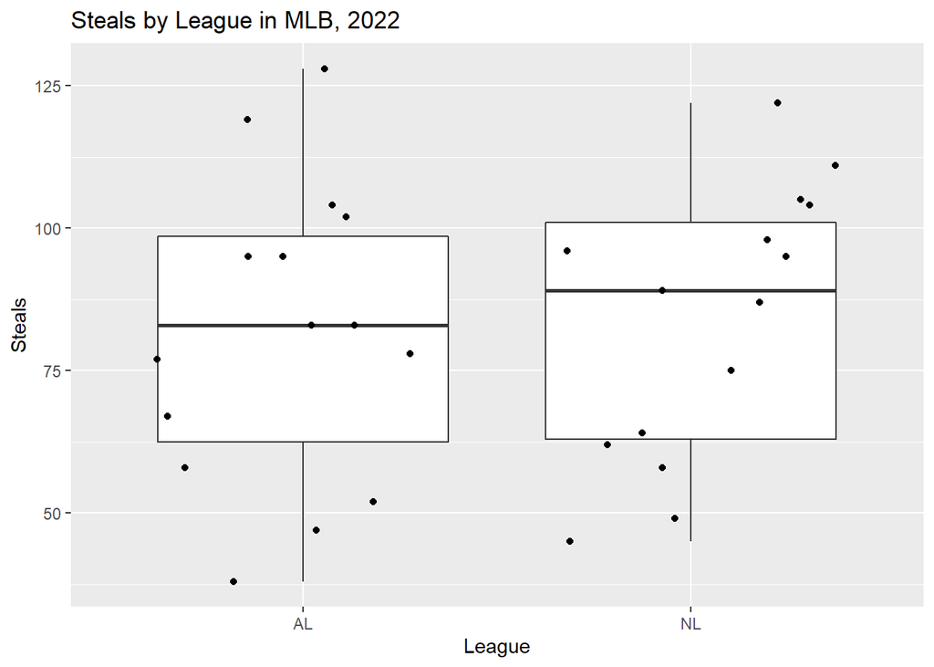

```r
teams_2022 %>% # Take 2022 data

  ggplot(aes(x = lgID, y = SB)) + # Set the x "aesthetic" to League (you'll see why we put lgID on the "x-axis" when you run it)
                                  # Set the y "aesthetic" to steals (that is, plot SB on the y-axis)

  geom_boxplot() + # Add a boxplot layer first

  geom_jitter(height = 0) + # Then add a second layer: a "jittered" scatterplot using geom_jitter
                            # Jittering adds a small amount of random noise to each point.
                            # To see why, try replacing this line with `geom_point()` instead.
                            # `height = 0` means no *vertical* jitter.


  labs(title = "Steals by League in MLB, 2022", # Add brief, descriptive title
       x = "League", y = "Steals") # Make better x and y axis labels
```

Another great option is returning to density plots, but this time splitting them:

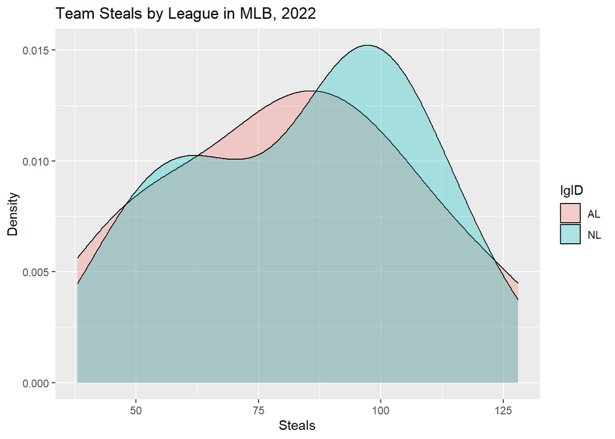

```r
teams_2022 %>% # Take 2022 data

  ggplot(aes(x = SB,           # Set the x "aesthetic" to steals, just like we did with runs in the density plot above
             fill = lgID)) +   # Instead of a y "aesthetic", we tell R to "fill" by League.
                               # ggplot understands this to mean you want the plot SPLIT AND filled by League.


  geom_density(alpha = 0.3) + # Create a density plot.
                              # `alpha=` controls the transparency of the curves; runs from 0-1, lower is more transparent.
                              # To see why we used it, try deleting it.

  labs(title = "Team Steals by League in MLB, 2022", # Add brief, descriptive title
       x = "Steals", y = "Density")                  # Make better x and y axis labels
```

**Lab Activity 12**:

1. Do you see any difference in the distribution of steals between AL and NL teams? Justify your thinking.
2. Is there any other pair of variables you’d like to investigate with charts like these?

## Quantifying Relationships Between Multiple Variables

We’ve talked about how to visualize but not how to *quantify* relationships between two variables.

### Correlation Coefficients

One way to look at the relationship between two continuous variables is with **correlation coefficients**, often denoted “**r**”. This is a number from -1 to +1 that summarizes the *linear* association between two variables (CAUTION: it does not capture other kinds of relationships!).

- -1 represents a perfect negative linear relationship (as `x` rises, `y` falls a perfectly predictable amount)
- 0 represents *no* linear relationship between x and y (as `x` rises, `y` moves unpredictably)
- +1 represents a perfect positive linear relationship (as `x` rises, `y` rises a perfectly predictable amount)

**Lab Activity 13**: Without checking, what do you think the correlation coefficient between runs scored and wins is?

Now let’s check.

```r
cor(teams_21c$R, teams_21c$W) # The syntax {DATA_FRAME}${VAR_NAME} references the indicated variable in the indicated data frame
```

```
## [1] 0.5873281
```

The correlation coefficient is often reported as the square of its value, called…well, “**r-squared**”. This is because r-squared as a nice interpretation: it is the percent of the variation in y explained by x.

```r
cor(teams_21c$R, teams_21c$W)^2
```

```
## [1] 0.3449543
```

This suggests that about 34.5% of the variation in a team’s win totals is explained by how many runs it scores.

**Lab Activity 14**:

1. Let’s re-do the above analyses for runs against (`RA`) rather than runs scored (`R`).
2. Which appears to be “more important” (that is, explains more about) a team’s win total?

#### Correlations Among 3+ Variables - Correlation Matrixes

What if we wanted to look at the relationships between a bunch of variables and wins, all at once?

For initially *exploring* how variables are related - but not for drawing final conclusions, which should always involve plotting data and likely regression models! - a quick first way is a **correlation matrix**. Let’s do this for runs (`R`), run differential (`rundiff`), and…what the hell, attendance vs. wins (`W`).

May I introduce you to `psych::pairs.panels()`?

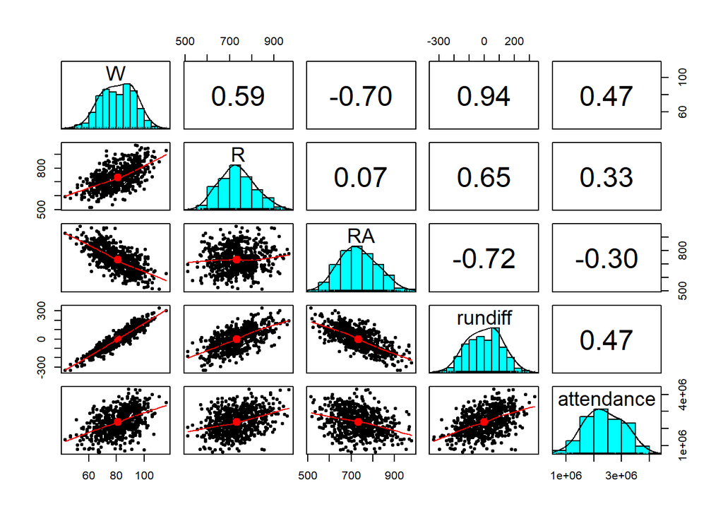

```r
teams_21c %>%
  select(W, R, RA, rundiff, attendance) %>%
  pairs.panels()
```

**Lab Activity 15**:

1. Which variables are most and least strongly associated with wins?
2. Why is attendance positively correlated with wins? Does greater attendance *cause* more wins?

   That’s always a good general lesson to remember: **CORRELATION DOES NOT EQUAL CAUSATION!!!**

### Simple Linear Regression

It’s a bad idea to rest any conclusions *purely* on correlation coefficients, though, as they’re [very limited in what they can tell you and can hide a lot of information](https://blog.revolutionanalytics.com/downloads/DataSaurus%20Dozen.gif).

A more complete approach includes plotting your raw data and visualizing their relationship with a **best-fit line** through your data. There are many ways to do this, but we’ll focus on one: **simple linear regression**. This is limited because it only fits a straight line, so it won’t work for non-linear relationships. But it’s a good introduction to the basic idea of quantifying relationships between variables with regression.

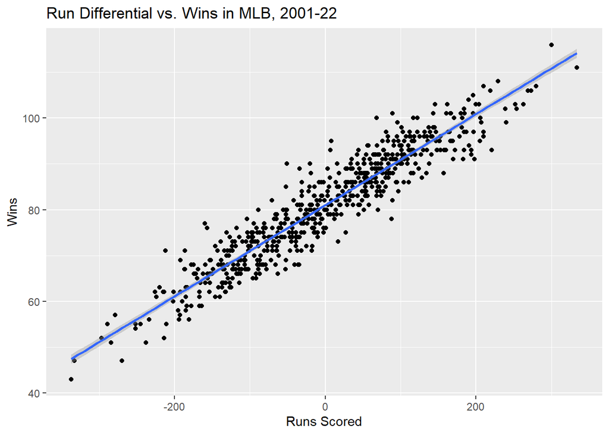

```r
# Plot a line of best fit through the data
teams_21c %>%
  ggplot(aes(x = rundiff, y = W)) +
  geom_point() +
  geom_smooth(method = "lm") + # Fits a simple linear regression model instead of a LOESS smoothing line
  labs(title = "Run Differential vs. Wins in MLB, 2001-22",
       x = "Runs Scored", y = "Wins")
```

```r
# Fit a simple linear regression model to get the line's equation
m1 <- lm(data = teams_21c, formula = W ~ rundiff)
summary(m1)
```

```
##
## Call:
## lm(formula = W ~ rundiff, data = teams_21c)
##
## Residuals:
##      Min       1Q   Median       3Q      Max
## -11.7290  -2.8435  -0.1198   2.5970  14.1015
##
## Coefficients:
##              Estimate Std. Error t value Pr(>|t|)
## (Intercept) 80.973016   0.162457  498.43   <2e-16 ***
## rundiff      0.099500   0.001415   70.31   <2e-16 ***
## ---
## Signif. codes:  0 '***' 0.001 '**' 0.01 '*' 0.05 '.' 0.1 ' ' 1
##
## Residual standard error: 4.078 on 628 degrees of freedom
## Multiple R-squared:  0.8873, Adjusted R-squared:  0.8871
## F-statistic:  4944 on 1 and 628 DF,  p-value: < 2.2e-16
```

**Lab Activity 16**: Let’s walk through the key parts of this output together.

## Conclusion and Credit

Now you’re well equipped to encounter data in R, explore it, do some basic manipulations to find interesting stats, and create a few basic plots. You can actually do quite a lot after just this one lab. Be proud!

Parts of this lab and HW were adapted from Mike Lopez’s Statistics in Sports course [here](https://github.com/statsbylopez/StatsSports20).

## Lab HW 1

Here are the questions for your first HW. You should answer these in an RMarkdown document, knit to **PDF** and submit on Canvas.

A template to help you format and structure this HW is available on Canvas alongside this tutorial. I strongly urge you to simply modify that template rather than starting a new RMarkdown document - it will be easier, faster, and result in a better assignment!

This HW is worth 10 points total.

**HW Q1**: Open the HW1 R Markdown template. Make sure you assign a proper name and title, but also change the date to November 19, 2022 (just so I know you figured out how to change it).

The title should be brief but descriptive. Like the headline on an article, it should communicate to the reader the topic of the document. Look at the title I gave this document (with the exception of the “Tutorial 1” part) - yours will likely be shorter, but it should accomplish the same goal. It should not be “Homework 1” or something similar - write to a general audience who may not know what “Homework 1” means. (1.0 pts)

**HW Q2**: Create a big heading for just this question. Now use `head()` and `str()` in a code chunk to explore the `Batting` data frame. (You should also use help pages + `View()` on your own, but don’t include those in your RMarkdown document as they won’t render well.)

Note that instead of player names there are `playerID`s. You can simply refer to players using their IDs, but if you can guess their names feel free to use those, too.

Once you’ve become familiar with the table explain your findings *in a brief paragraph*, including:

A. How many rows are there?

B. How many columns are there?

C. What do you think each row represents?

D. What does the `SO` column’s value in the last row represent, in words? Tip to easily view the last row: we learned about the `head()` function, but there is also a corresponding `tail()` function. (2 pts)

**HW Q3**: Create another broad heading for this and all following questions. I’ve included a suggested heading in the template for this assignment as an example of a good one, but feel free to edit it! Headings really help readers understand and navigate your documents. (0.5 pts)

**HW Q4**: Create a sub-heading for this question. Then create a new data frame with only `playerID`, team, year, and number of home runs, and print the rows with the 6 highest home run values. Explain your findings in 1-2 sentences. (1.5 pts)

**HW Q5**: Create another sub-heading for this question. Which player holds the record for most triples *per game* in a season (minimum 50 games played that season) from the last 10 seasons, and in which year did he do it? You can just print your result here, no explanation required if you have a sufficiently descriptive heading. (1.5 pts)

**HW Q6**: Create another sub-heading for this question. Produce a data frame containing each player’s total number of double plays they grounded into (`GIDP`) during the last 10 seasons. Who hit into the most, and how many was it? The data frame should have one row per player. Print the top 7 results. You can just print your result here, no explanation required if you have a sufficiently descriptive heading. (1.5 pts)

**HW Q7**: Create another sub-heading for this question.

Create any visualization you want using the `Batting` data frame. Most likely you’ll want to just modify some of the code we used above to keep things simple, but the question you investigate is up to you. Do something that interests you! Explain/interpret your visualization in 1-2 sentences. If it provides any insights into the sport (it doesn’t have to), explain them. (2 pts)